# Datenvisualisierung mit R

Nützliche Werkzeuge – Daten umformen und weitere Darstellungsarten

Armin Schäfer

schaefer@politik.uni-mainz.de

05.06.2025

[figure not shown]

## Wiederholung: Warum `%>%` nutzen?

Stellen Sie sich vor, wir möchten wissen, wer die 10 jüngsten Abgeordneten des Bundestags sind. Dafür müssen wir die Daten sortieren (`arrange`) und dann die ersten 10 Zeilen auswählen (`slice`):

Ohne `%>%`

```r
junge_abgeordnete <- arrange(bundestag, alter)
junge_abgeordnete <- slice(junge_abgeordnete, 1:10)

junge_abgeordnete <- slice(arrange(bundestag, alter), 1:10)
```

Mit `%>%`

```r
junge_ageordnete <-
  bundestag %>%
  arrange(alter) %>%
  slice(1:10)
```

Der `%>%`-Operator macht den Code leichter lesbar.

## Rückblick

geom_histogram()

geom_density()

geom_point()

geom_jitter()

geom_boxplot()

geom_violin()

## Verteilung in Gruppen – `geom_boxplot()`

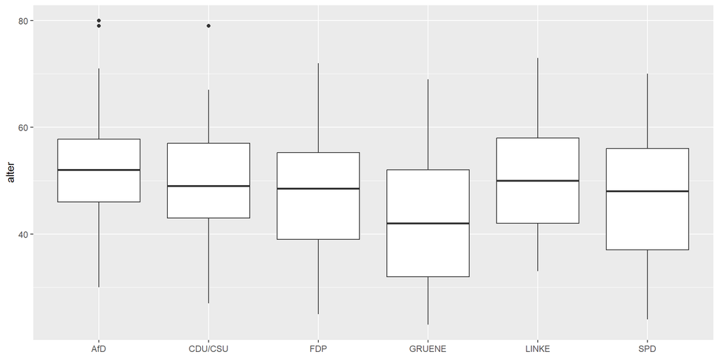

```r
ggplot(data = bundestag, aes(x = partei, y = alter))+
  geom_boxplot()+
  labs(x = NULL)
```

Die Abgeordneten der Grünen haben das niedrigste Medianalter.

## Boxplot: ein visuelles Problem

Obwohl Boxplots in den Sozialwissenschaften verbreitet sind, stellen sie die meisten Betrachter:innen vor Probleme, weil…

- die Antennen nicht die gesamte Verteilung der Daten anzeigen,
- unklar ist, nach welchen Regeln Außreißer angezeigt werden,
- viele Menschen nicht mit dem Median vertraut sind,
- nicht offensichtlich ist, was die Größe der Box aussagt.

Deshalb könnte es nützlich sein, zusätzlich **alle zugrundeliegenden Datenpunkte** darzustellen.

## Zwei Geome kombinieren

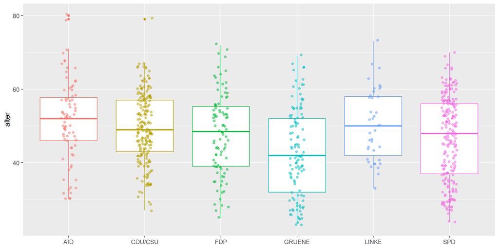

```r
ggplot(data = bundestag, aes(x = partei, y = alter, color = partei))+
  geom_boxplot()+
  geom_jitter(alpha = 0.5, width = 0.1)+
  labs(x = NULL)+
  guides(color = FALSE)
```

Was passiert, wenn Sie die Reihenfolge der Geome verändern?

## Zwei Geome kombinieren

Was hat sich verändert?<sup>1</sup>

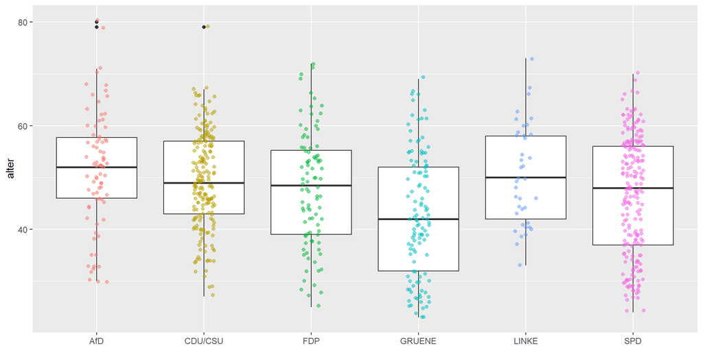

```r
ggplot(data = bundestag, aes(x = partei, y = alter))+
  geom_boxplot()+
  geom_jitter(aes(color = partei), alpha = 0.5, width = 0.1)+
  labs(x = NULL)+
  guides(color = FALSE)
```

[^1]: Hier wäre es sinnvoll, die Outlier zu entfernen, da diese Punkte ohnehin durch `geom_jitter()` dargestellt werden: `geom_boxplot(outlier.shape = NA)`.

## Wo werden `aesthetics` festgelegt?

**Wichtig**

`aes()` legt fest, wie Daten in sichtbare Elemente übersetzt werden: z.B. in Farben, Formen, Schattierungen. Wenn wir `aes()` innerhalb von `ggplot()` bestimmen, gelten die Angaben für *alle Geome* der Grafik. Wollen wir `aes()` nur auf einzelne Geome anwenden, muss die Festlegung dort erfolgen. Z.B. `geom_jitter(aes(color = partei))`.

## Zwei Geome kombinieren

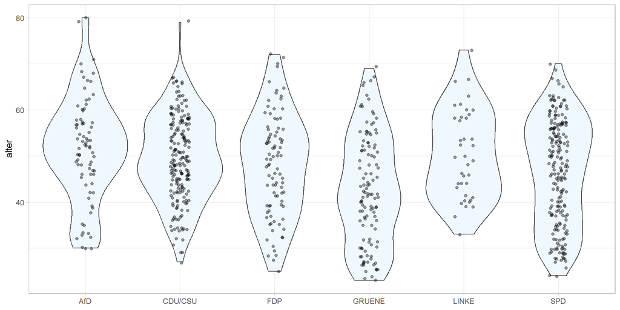

```r
ggplot(data = bundestag, aes(x = partei, y = alter))+
  geom_violin(fill = "aliceblue")+
  geom_jitter(alpha = 0.4, width = 0.1)+
  labs(x = NULL)+
  theme_light()
```

## Drei Geome kombinieren

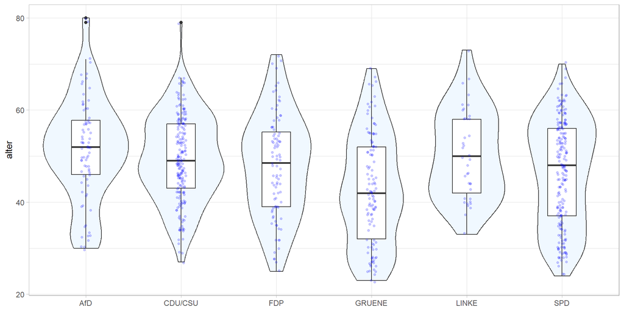

```r
ggplot(data = bundestag, aes(x = partei, y = alter))+
  geom_violin(fill = "aliceblue")+
  geom_boxplot(width=0.3)+
  geom_jitter(color = "blue", alpha = 0.2, width = 0.05, size = 1)+
  labs(x = NULL)+
  theme_light()
```

## Zwei Geome kombinieren

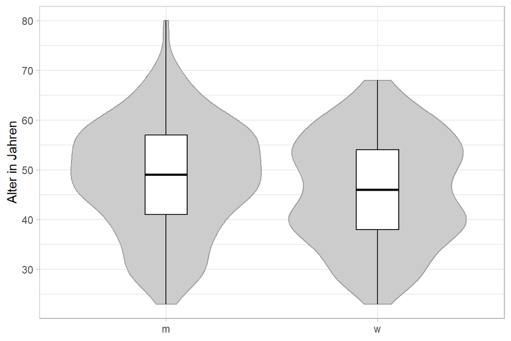

```r
ggplot(data = bundestag, aes(x = geschlecht, y = alter))+
  geom_violin(color = "grey60", fill = "grey80")+
  geom_boxplot(color = "black", fill = "white", width=0.2)+
  scale_y_continuous(breaks = seq(20, 80, by = 10))+
  labs(x = NULL, y = "Alter in Jahren")+   theme_light()
```

## Für zu Hause

Diese Grafik ist mit der Bibliothek `ggbeeswarm` erstellt worden. Sie können zu Hause versuchen, sie so genau wie möglich nachzubauen (keine Pflicht).

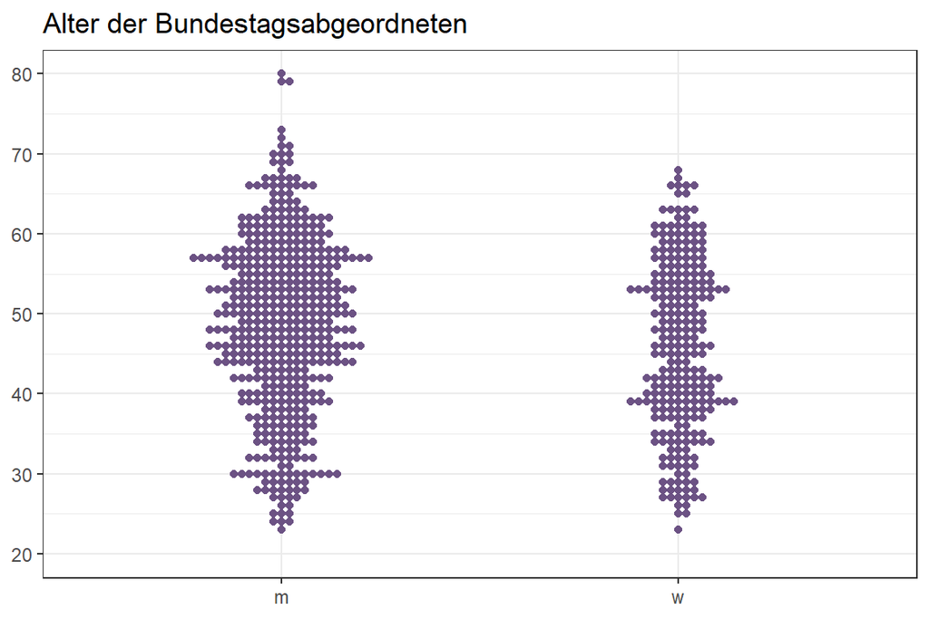

## ggbeeswarm()

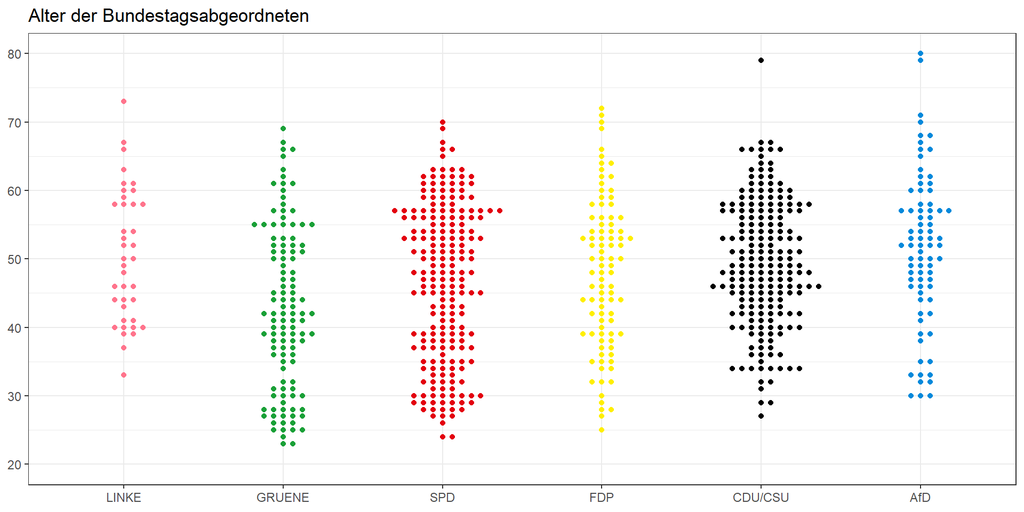

# Datensätze bearbeiten

## Daten

Bitte laden Sie die Datei bundestag_comp.xlsx aus dem Order “Datensätze” in Moodle herunter und speichern Sie ihn im Ordner “data”.

Fügen Sie den passenden Befehl in Ihr Skript ein, um den Datensatz als “bt_comp” zu speichern.

```r
bt_comp <- import(here("data", "bundestag_comp.xlsx"))
```

## Welche Parteien sind enthalten?

```r
table(bt_comp$partei)
```

```
                     AfD       AfD - Fraktionslos                      CDU
                      80                        1                      152
                     CSU                DIE LINKE                      FDP
                      45                       39                       92
Fraktionslos (AfD-Liste)                   GRUENE                      SPD
                       2                      118                      206
                     SSW
                       1
```

Vier Abgeordnete gehören keiner Fraktion oder dem SSW an. Um die Darstellung zu vereinfachen, entfernen wir sie mit dem Befehl `filter()` aus dem Datensatz.

## Beobachtungen filtern

Geben Sie nacheinander folgende Befehle **in die Konsole** ein:

`bt_comp %>% filter(partei == "CDU")`.

`bt_comp %>% filter(partei != "CDU")`.<sup>1</sup>

`bt_comp %>% filter(partei == "CDU" | partei == "SPD")`.<sup>2</sup>

[^2]: Die `!` heißt “nicht”.
[^3]: Das Zeichen `|` steht für “oder”.

## Beobachtungen filtern mit `%in%`

Wenn wir viele Gruppen eines Faktors filtern möchten, ist der Weg mit der “Oder”-Verknüpfung mühselig, weil wir immer wieder “`| partei ==`” schreiben müssten. Stattdessen können wir den Operator %in% verwenden, der “aus der nachfolgenden Liste” bedeutet.

```r
parteiliste <- c("Fraktionslos (AfD-Liste)", "AfD - Fraktionslos", "SSW")

bt <- bt_comp %>% # wir verwenden einen neuen Namen!
  filter(partei %in% parteiliste)

table(bt$partei)
```

```
      AfD - Fraktionslos Fraktionslos (AfD-Liste)                      SSW
                       1                        2                        1
```

Was müssen wir machen, um diese vier Abgeordneten *auszuschließen*?

## Beobachtungen ausschließen mit `%in%`

```r
bt <- bt_comp %>%
  filter(!partei %in% parteiliste) # wir fügen das Nichtzeichen hinzu.

table(bt$partei)
```

```
      AfD       CDU       CSU DIE LINKE       FDP    GRUENE       SPD
       80       152        45        39        92       118       206
```

## Faktorenlevel verändern – `case_match()`

Statt CDU und CSU getrennt voneinander zu betrachten, fügen wir sie zusammen. Dafür verwenden wir das Kommando `mutate()` in Kombination mit `case_match()`.

```r
bt <- bt_comp %>%
  mutate(partei = case_match(
    partei,
    "CDU" ~ "CDU/CSU", # alter Name ~ neuer Name
    "CSU" ~ "CDU/CSU", # alter Name ~ neuer Name
    .default = partei)) # alle anderen Namen bleiben gleich
```

## Faktorenlevel verändern – `case_match()`

Dasselbe in einer Zeile

```r
bt <- bt_comp %>%
  mutate(partei = case_match(
    partei,
    c("CDU", "CSU") ~ "CDU/CSU", # alte Namen ~ neuer Name
    .default = partei)) # alle anderen Namen bleiben gleich
```

Wenden Sie `case_match()` an, um “DIE LINKE” in “LINKE” umzubenennen. Prüfen Sie mit `table()`.

## Faktorenlevel umbenennen

```r
bt <- bt_comp %>%
  mutate(partei = case_match(
    partei,
    c("CDU", "CSU") ~ "CDU/CSU",
    "DIE LINKE"     ~ "LINKE",
    .default = partei))
```

Das Kommando `case_match()` bedeut, “wenn … dann”. Eng verwandt damit ist `case_when()`, das aber nicht die sehr nützliche `.default`-Option enthält.

## Case_when()

Wir nutzen jetzt `case_when()`, um die Parteinamen klein zu schreiben. Da wir das nicht dauerhaft behalten wollen, speichern wir den Datensatz als “test” ab.

```r
test <- bt %>%
  mutate(partei = case_when(
    partei == "LINKE"   ~ "linke", # beachten Sie das doppelte Gleichzeichen
    partei == "GRUENE"  ~ "gruene",
    partei == "SPD"     ~ "spd",
    partei == "FDP"     ~ "fdp",
    partei == "CDU/CSU" ~ "cdu/csu",
    partei == "AFD"     ~ "afd"))

rm(test) # rm steht für remove
```

## Variablen umbenennen

```r
bt <- bt %>%
  rename(gender = geschlecht) %>%  # neuer Name = alter Name
  mutate(gndr = gender)           # fügt eine neue Spalte mit neuem Namen hinzu
```

## Fehlende Werte anzeigen lassen

```r
table(bt$gender, useNA = "ifany")
```

```
-999    0    1
   5  476  255
```

## Zahlen in Missings umwandeln mit `ifelse()`

```r
test <- bt %>%
  mutate(gender = ifelse(gender == -999, NA, gender))
```

Der Befehl sagt, wenn gender einen bestimmten Wert annimmt (-999), wandele diese Wert in einen fehlenden Wert (NA) um, falls die Variable einen anderen Wert hat, behalte den Originalwert (gender) bei.

## Zahlen in Missings umwandeln mit `case_when()`

```r
bt <- bt %>%
  mutate(gender = case_when(
    gender == 0 ~ "m",
    gender == 1 ~ "w"))
```

**Warnung**

Wir nutzen hier, dass alle Werte einer Variable, denen mit `case_when()` **kein neuer Wert zugewiesen wird**, automatisch in `NA` umgewandelt werden. Vergessen Sie also ein Faktorenlevel bei der Umbenennung, wird dieses zu einem fehlenden Wert!

## Fehlende Werte in `ggplot()`

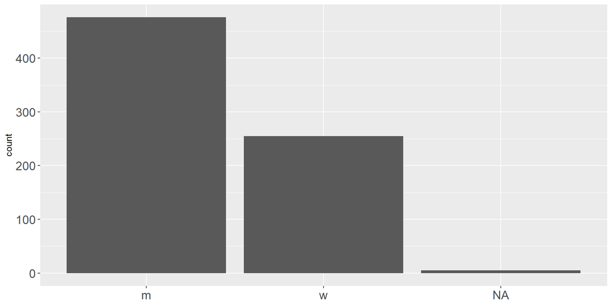

```r
ggplot(data = bt, aes(x = gender))+
  geom_bar()+
  labs(x = NULL)+
  theme(axis.text = element_text(size = 14))
```

**Wichtig**

Fehlende Werte werden als eigene Kategorie in Grafiken dargestellt. Falls wir das nicht wollen, müssen wir es R mitteilen.

## Fehlende Werte in `ggplot()` vorab filtern

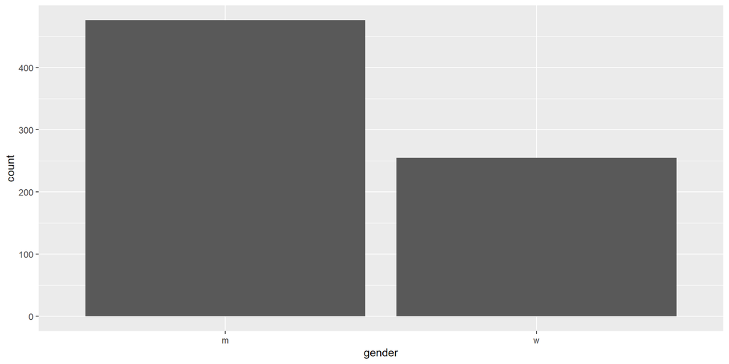

```r
bt %>%
  filter(!is.na(gender)) %>% # gender ist nicht NA
ggplot(aes(x = gender))+
  geom_bar()
```

Der Befehl `is.na()` identifiziert Zeilen mit NA. Wollen wir sie ausschließen, müssen wir R sagen, dass nur Zeilen beachtet werden, die **keine fehlende Werte** sind: `!is.na()`.

## Eine neue Variable erstellen

Statt des Geburtsjahrs wollen wir im Datensatz `bt` das Alter verwenden. Erstellen Sie eine **neue Spalte**, die diese Information enthält und ermitteln Sie in einem zweiten Schritt das Durchschnittsalter der Abgeordneten.

## Eine neue Variable erstellen

```r
bt <- bt %>%
 mutate(alter = 2021-geburtsjahr)

mean(bt$alter)
```

```
[1] 47.5231
```

Die Abgeordneten sind im Durchschnitt 47.5 Jahre alt.

## Alles in einer Kette mit `%>%`

```r
bt <- bt_comp %>%
  filter(!partei %in% parteiliste) %>%
  rename(gender = geschlecht) %>%
  mutate(
    partei = case_match(partei,
        c("CDU", "CSU") ~ "CDU/CSU",
        "DIE LINKE"     ~ "LINKE",
        .default = partei)) %>%
  mutate(alter = 2021-geburtsjahr) %>%
  mutate(gender = case_when(
    gender == 0 ~ "m",
    gender == 1 ~ "w"))
```

```r
bt <- bt_comp %>%
  filter(!partei %in% parteiliste) %>%
  rename(gender = geschlecht) %>%
  mutate(
    partei = case_match(partei,
        c("CDU", "CSU") ~ "CDU/CSU",
        "DIE LINKE"     ~ "LINKE",
        .default = partei),
    alter = 2021-geburtsjahr,
    gender = case_when(
      gender == 0 ~ "m",
      gender == 1 ~ "w"))
```

## Von Individuen zu Gruppen

**Warnung**

In den nächsten Schritten speichern wir den Datensatz nicht ab!

```r
bt %>%
  group_by(partei) %>%
  tally() # zählt, wie viele Fälle die Auspragungen des Faktors "partei" haben.
```

```
# A tibble: 6 × 2
  partei      n
  <chr>   <int>
1 AfD        80
2 CDU/CSU   197
3 FDP        92
4 GRUENE    118
5 LINKE      39
6 SPD       206
```

## Von Individuen zu Gruppen

Äquivalent zu `group_by()` und `tally()`.

```r
bt %>% group_by(partei) %>% # lieber nicht in eine Zeile (ich spare Platz)
  summarise(n = n()) # das erste "n" ist der neue Spaltenname, nicht sinnvoll!
```

Besser:

```r
bt %>% group_by(partei) %>%
  summarise(obs_per_party = n())
```

```
# A tibble: 6 × 2
  partei  obs_per_party
  <chr>           <int>
1 AfD                80
2 CDU/CSU           197
3 FDP                92
4 GRUENE            118
5 LINKE              39
6 SPD               206
```

## Durchschnitt pro Gruppe

```r
bt %>%
  group_by(partei) %>%
  summarise(mean_alter = mean(alter, na.rm=TRUE))
```

```
# A tibble: 6 × 2
  partei  mean_alter
  <chr>        <dbl>
1 AfD           51.4
2 CDU/CSU       49.3
3 FDP           47.9
4 GRUENE        42.7
5 LINKE         50.4
6 SPD           46.4
```

**Wichtig!**

Gewöhnen Sie sich an, im Befehl `mean()` immer `na.rm=TRUE` hinzuzufügen.<sup>1</sup> Sobald fehlende Werte in der Spalte vorhanden sind, funktioniert der Befehl nicht mehr.

[^4]: `NA` sind fehlende Werte und der Befehl sagt, dass sie entfernt werden sollen.

Datenvisualisierung